# Social Networks Analysis in One Health Epidemiology with R

Andrzej Jarynowski (ajarynowski@gmail.com)

Vitaly Belik (vitaly.belik@fu-berlin.de)

17 March, 2019

In our tutorial we used materials by John M. Drake, Mateo Mangani, Sharon Kuhman, Michal Burdukiewicz and Katya Ognyanova and Eric Kolaczyk.

In this workshop we introduce an igraph R package to analyze social networks represented within the more general framework of disease spread.

To introduce the problem we will use the African Swine Fever spread in Poland case. Each type of relation (pig production supply chain, wild board density, human mobility) defines a network between counties: *vertices* (or *nodes*) represent counties *edges* connect adjacent vertices (possibility of transmitting infection.

*SNA In R* Network generations Network plotting Layouts Degree distribution Centrality Giant component and percolation Paths

analyse it (degrees, other metrics, may be communities) export into format for visualization (using ndtv package in R) produce a html embeddeded visualization of the network (using ndtv package in R)

*Modelling (outside of R)* SIR spreadsheet VENSIM SIR (system dynamics) Python (differential equations) Compare standard epi-model (solve ODEs): SI, SIS, SIR, SIRS Compare them to network (still ODES) Compare to stochastic epidemics on a network Run epidemics on a grid (ODES), Epidemic wave (spatial propagation) Time series analysis (surveillance package) Agent Based Modelling (Netlogo http://sirsz.pl/data/materialy/szpital2.html) Food outbreak investigation (https://foodrisklabs.bfr.bund.de/foodchain-lab/ )

*ASF Example*

Maps Generating

ASF Data: - Event Data (for say around 50 counties) - Network based on geographical distance [- provide human, forest, pig density for network construction?] - Network based on the effective distance (with fitted last time parameters) - Network based on the correlation of time events

Tasks: - plot the networks (only topology), compare them - analyse them (degrees, centrality etc.) - check for correlations of arrival times and effective distance network (here we will provide shortest path routine to calculate the effective shortest path)

# 1 Social Network Analysis in R

We start by loading the library an playing with network

```r
# install.packages("igraph","dplyr", "ggplot2", "surveillance", "scales", "deSolve")

library(igraph)
library(dplyr)
library(surveillance)
library(ggplot2)
library(scales)
#library(deSolve)
```

Then we can create netorwks

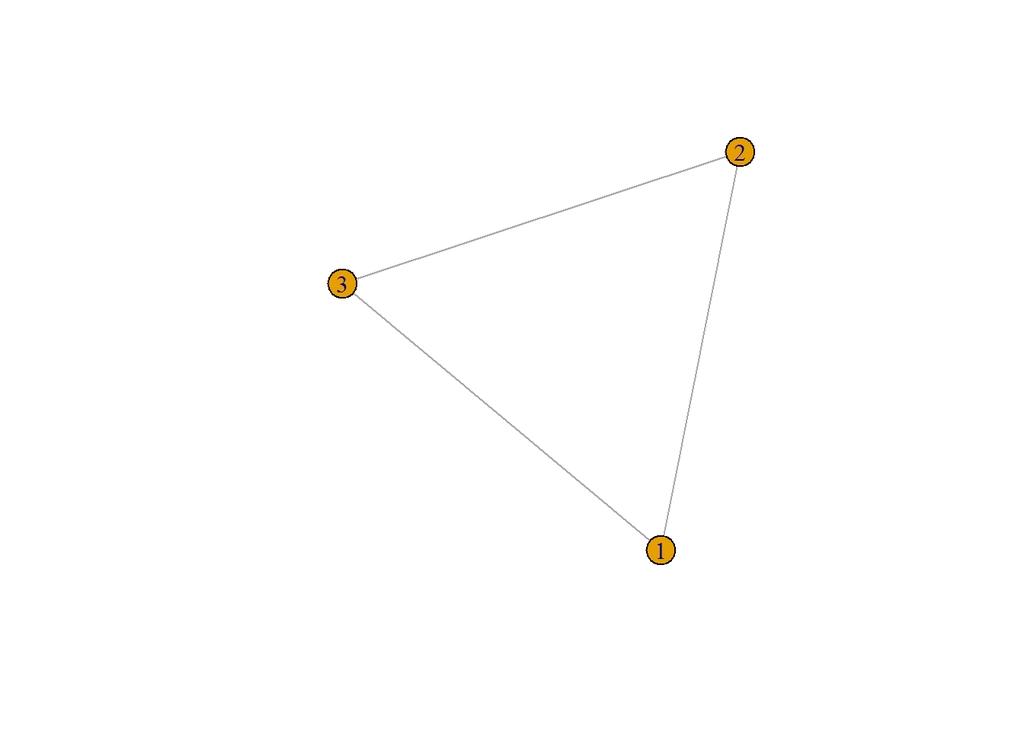

```r
#  ------->> Create networks --------

g4 <- graph( edges=c(1,2, 2,3, 3,1), n=3, directed=F ) # an undirected graph with 3 edges
# The numbers are interpreted as vertex IDs, so the edges are 1-->2, 2-->3, 3-->1
plot(g4) #
```

```r
#  ------->> Edge, vertex, and network attributes --------

# Access vertices and edges:
E(g4) # The edges of the object
```

```
## + 3/3 edges from dc234ee:
## [1] 1--2 2--3 1--3
```

```r
V(g4) # The vertices of the object
```

```
## + 3/3 vertices, from dc234ee:
## [1] 1 2 3
```

```r
# You can examine the network matrix directly:
g4[]
```

```
## 3 x 3 sparse Matrix of class "dgCMatrix"
##
## [1,] . 1 1
## [2,] 1 . 1
## [3,] 1 1 .
```

```r
g4[1,]
```

```
## [1] 0 1 1
```

```r
# Add attributes to the network, vertices, or edges:
V(g4)$name # automatically generated when we created the network.
```

```r
V(g4)$gender <- c("male", "male", "female")
E(g4)$type <- "email" # Edge attribute, assign "email" to all edges
E(g4)$weight <- 10    # Edge weight, setting all existing edges to 10

# Examine attributes
edge_attr(g4)
```

```
## $type
## [1] "email" "email" "email"
##
## $weight
## [1] 10 10 10
```

```r
vertex_attr(g4)
```

```
## $gender
## [1] "male"   "male"   "female"
```

```r
graph_attr(g4)
```

```
## named list()
```

Networks can be read from file. The format allows us to specify various details, such as the directionality.

We can create or generate networks.

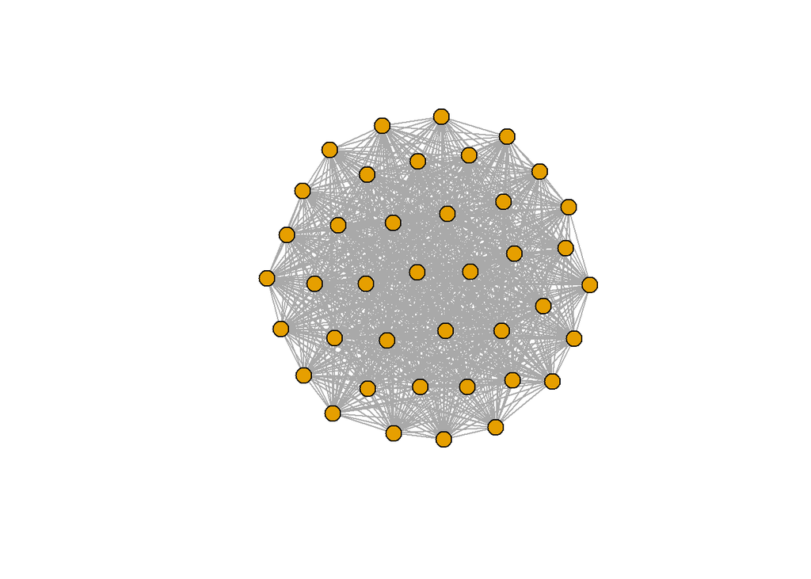

```r
# Full graph
fg <- make_full_graph(40)
plot(fg, vertex.size=10, vertex.label=NA)
```

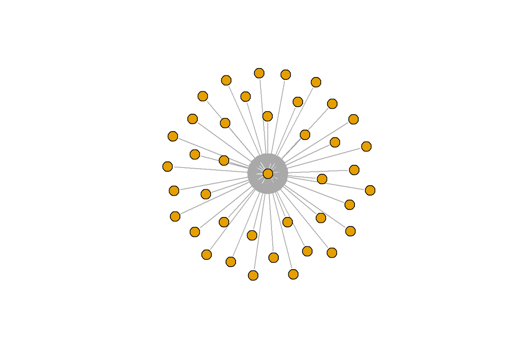

```r
# Star graph
st <- make_star(40)
plot(st, vertex.size=10, vertex.label=NA)
```

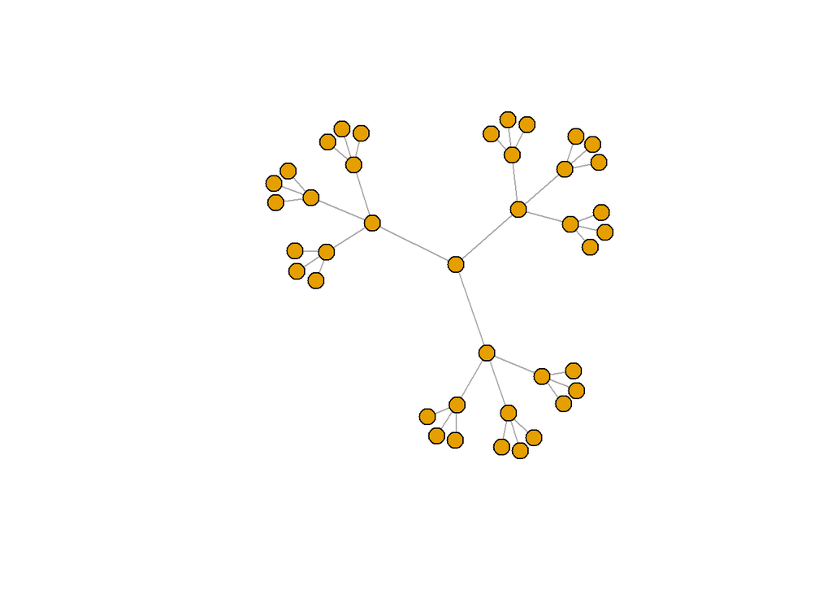

```r
# Tree graph
tr <- make_tree(40, children = 3, mode = "undirected")
plot(tr, vertex.size=10, vertex.label=NA)
```

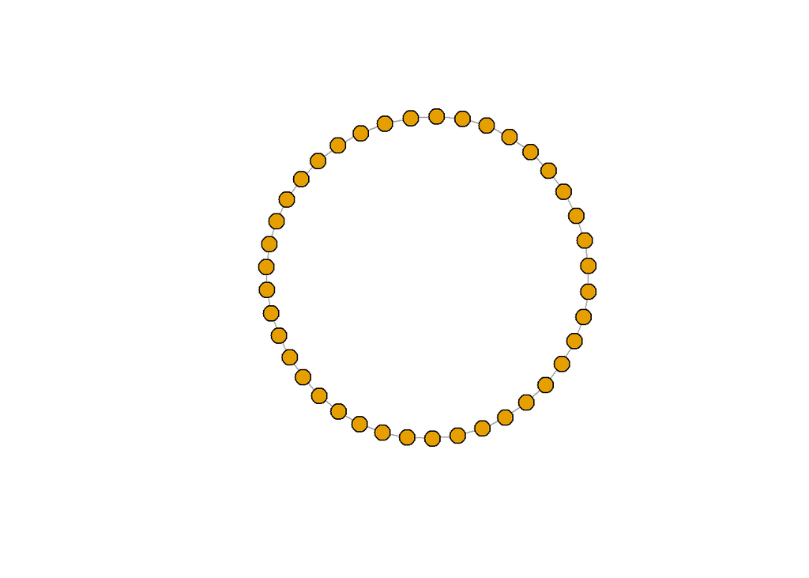

```r
# Ring graph
rn <- make_ring(40)
plot(rn, vertex.size=10, vertex.label=NA)
```

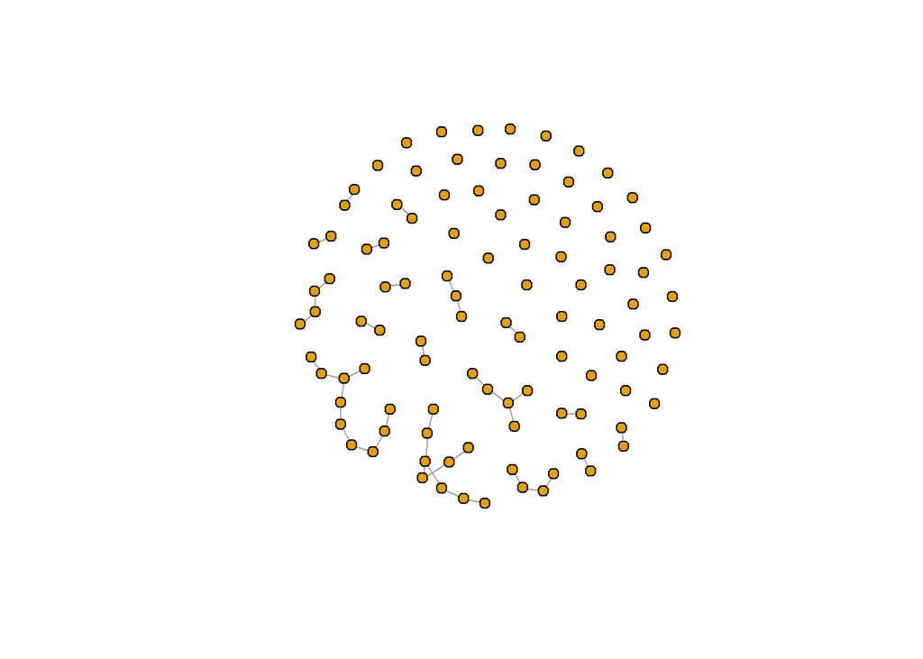

```r
# Erdos-Renyi random graph
# ('n' is number of nodes, 'm' is the number of edges)
er <- sample_gnm(n=100, m=40)
plot(er, vertex.size=6, vertex.label=NA)
```

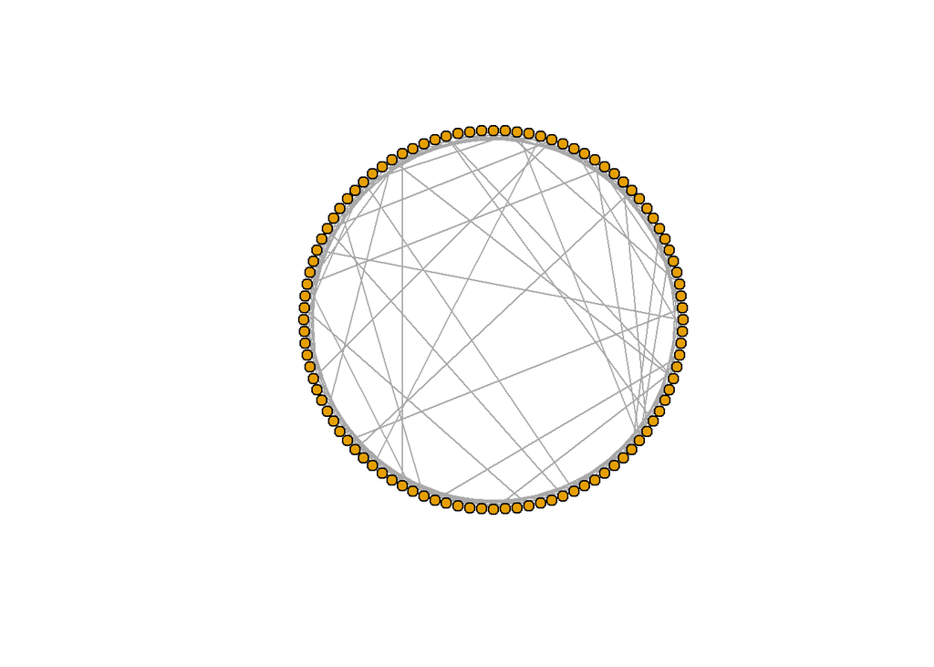

```r
# Watts-Strogatz small-world graph
# Creates a lattice with 'dim' dimensions of 'size' nodes each, and rewires edges
# randomly with probability 'p'. You can allow 'loops' and 'multiple' edges.
# The neighborhood in which edges are connected is 'nei'.
sw <- sample_smallworld(dim=2, size=10, nei=1, p=0.1)
plot(sw, vertex.size=6, vertex.label=NA, layout=layout_in_circle)
```

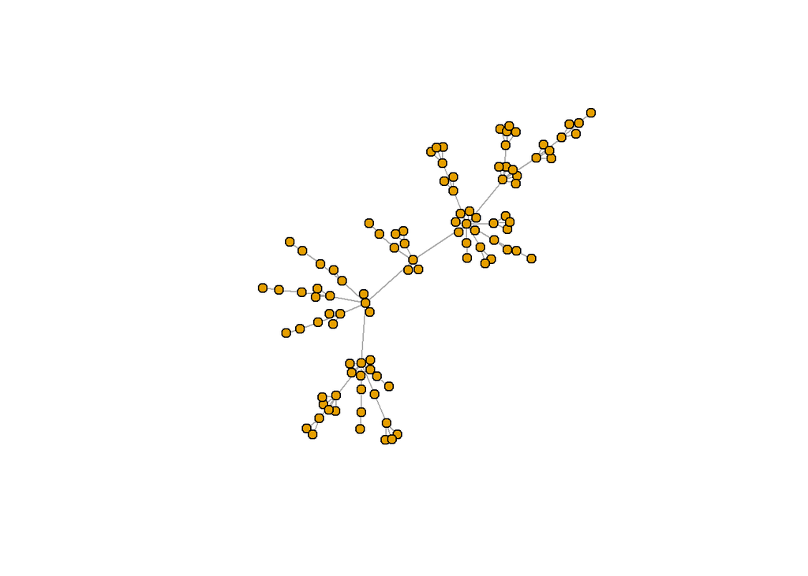

```r
# Barabasi-Albert preferential attachment model for scale-free graphs
# 'n' is number of nodes, 'power' is the power of attachment (1 is linear)
# 'm' is the number of edges added on each time step
ba <-  sample_pa(n=100, power=1, m=1,  directed=F)
plot(ba, vertex.size=6, vertex.label=NA)
```

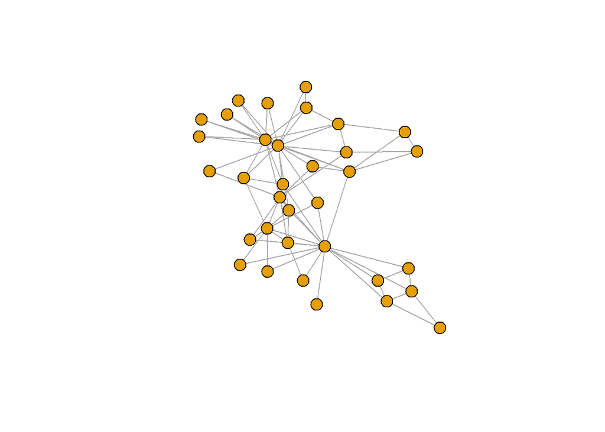

```r
#igraph can also give you some notable historical graphs. For instance:
zach <- graph("Zachary") # the Zachary carate club
plot(zach, vertex.size=10, vertex.label=NA)
```

Networks can be read from file. Adjacency matrix allows us to specify various details, such as the directionality

```r
# matrix - dependency matrix for most likely introduction routes (transmission risk between counties)
load("data.RData")

net=graph_from_adjacency_matrix(matrix,  weighted=TRUE, mode="directed")

#list - ASF introduction times to Polish counties (till 2017) with their characteristics (pig density, forest coverage, coordinates)

list
```

```
##     id   Disctrict Date.of.start.event arrival_time        x        y
## 1   28   PODLASKIE             2/10/14            1 23.23675 53.09906
## 2  183   PODLASKIE             2/12/14            2 23.42769 53.46236
## 3   82   PODLASKIE             3/19/15          402 23.58315 52.74800
## 4  254   PODLASKIE             2/12/16          732 22.89823 52.48321
## 5   25   LUBELSKIE             3/11/16          760 23.21001 51.97427
## 6  305   PODLASKIE             4/10/16          790 22.79182 53.41039
## 7   52 MAZOWIECKIE             7/11/16          882 22.84078 52.22479
## 8  222   PODLASKIE             7/31/16          902 22.56544 52.87631
## 9  262   PODLASKIE             10/8/16          971 22.26071 53.00715
## 10  29   PODLASKIE             11/8/16         1002 23.05650 52.74810
## 11 213   LUBELSKIE              1/8/17         1063 23.40782 51.49634
## 12 251   PODLASKIE             1/10/17         1065 23.30439 54.08700
## 13  75   PODLASKIE             1/17/17         1072 22.48098 53.55778
## 14 241   LUBELSKIE              2/8/17         1094 22.67976 51.79367
```

[output cut: 23 more lines]

```r
V(net)$names=list$county
```

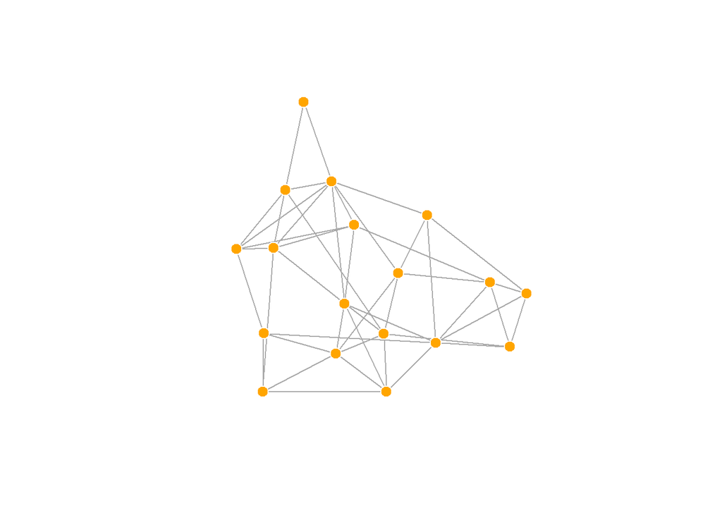

```r
V(net)$size <- 8
V(net)$frame.color <- "white"
V(net)$color <- "orange"
V(net)$label <- ""
E(net)$arrow.mode <- 0
plot(net)
```

Before performing a quantitative analysis we can plot the network, to get a first idea of its structure. We can produce a default visualization just by executing plot(net), but to make the plot more readable we will add a few details.You can set the layouts here.

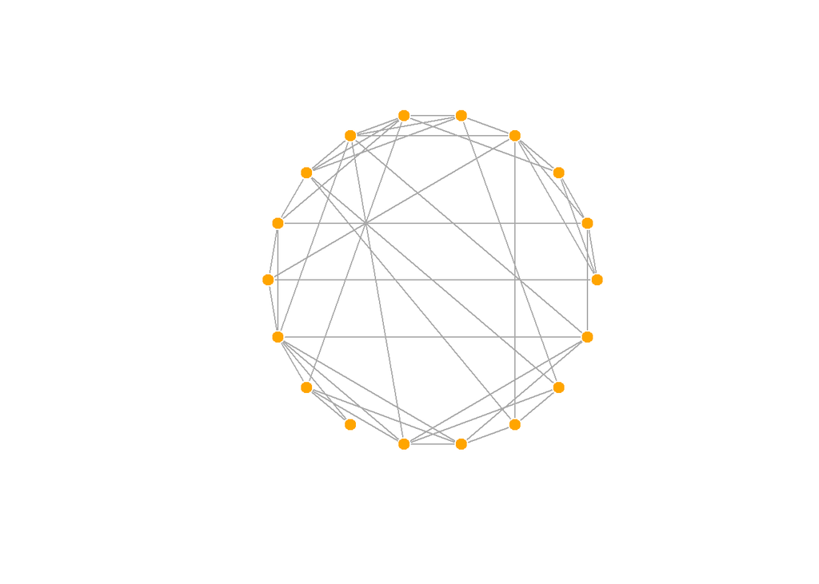

```r
l <- layout_in_circle(net)
plot(net, layout=l)
```

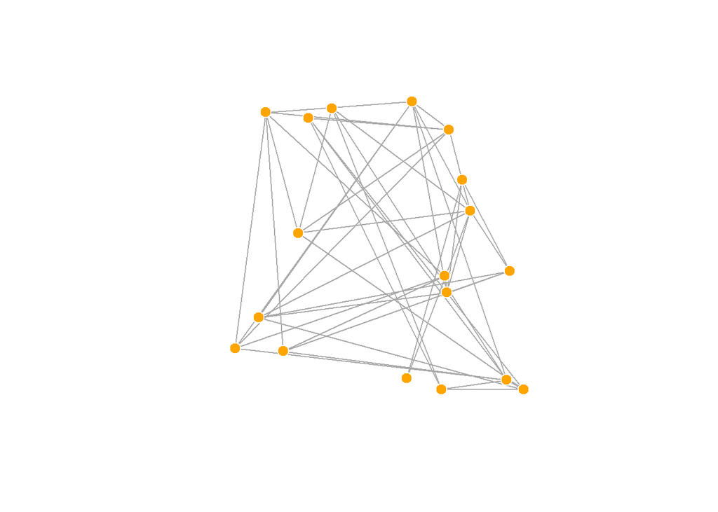

```r
# igraph has a number of built-in layouts, including:

# Randomly placed vertices
l <- layout_randomly(net)
plot(net, layout=l)
```

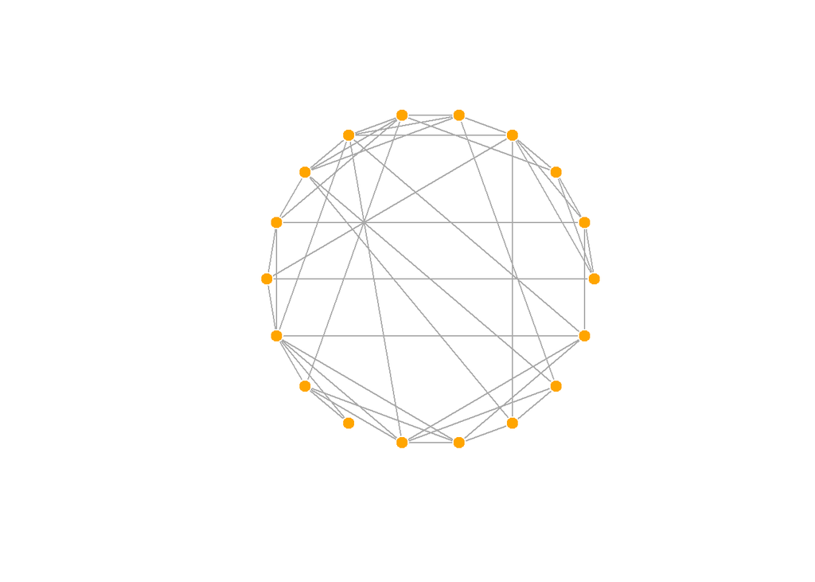

```r
# Circle layout
l <- layout_in_circle(net)
plot(net, layout=l)
```

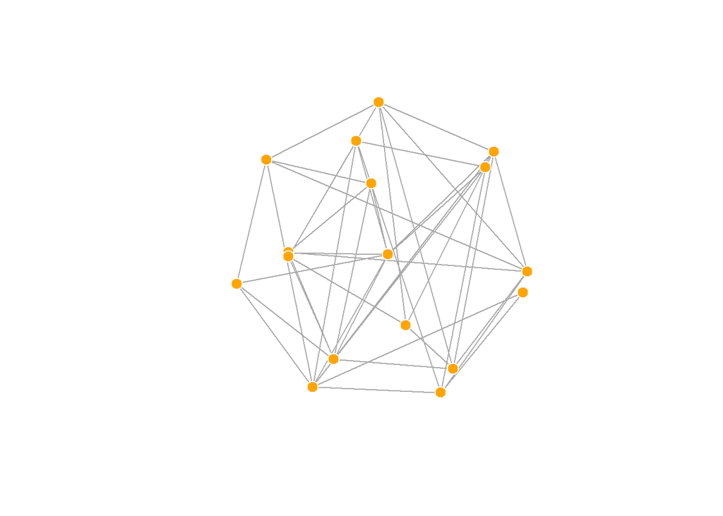

```r
# 3D sphere layout
l <- layout_on_sphere(net)
plot(net, layout=l)
```

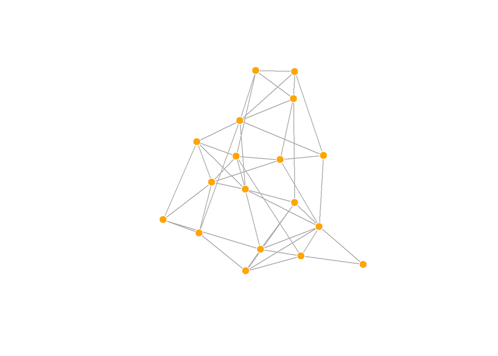

```r
# The Fruchterman-Reingold force-directed algorithm
# Nice but slow, most often used in graphs smaller than ~1000 vertices.
l <- layout_with_fr(net)
plot(net, layout=l)
```

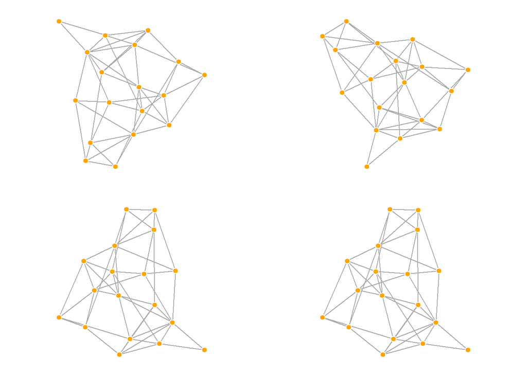

```r
# You will also notice that the layout is not deterministic - different runs
# will result in slightly different configurations. Saving the layout in l
# allows us to get the exact same result multiple times.
par(mfrow=c(2,2), mar=c(1,1,1,1))
plot(net, layout=layout_with_fr)
plot(net, layout=layout_with_fr)
plot(net, layout=l)
plot(net, layout=l)
```

```r
dev.off()
```

In particular, we explicitly compute a layout that draws counties at geographical cooridinates.

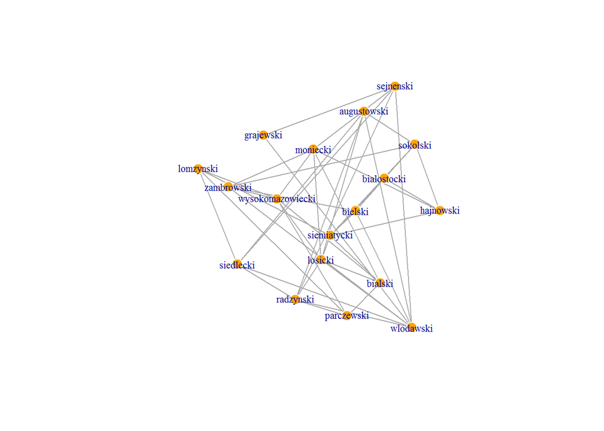

```r
V(net)$x=list$x
V(net)$y=list$y
# coordinates (centroids of counties)
#V(net)$District=list$District

lay=matrix(data=c(V(net)$x,V(net)$y), nrow=18, ncol=2)

plot.igraph(net, vertex.size=9, vertex.label=V(net)$names, vertex.label.cex=0.7, edge.arrow.size=0.3, layout=lay )
```

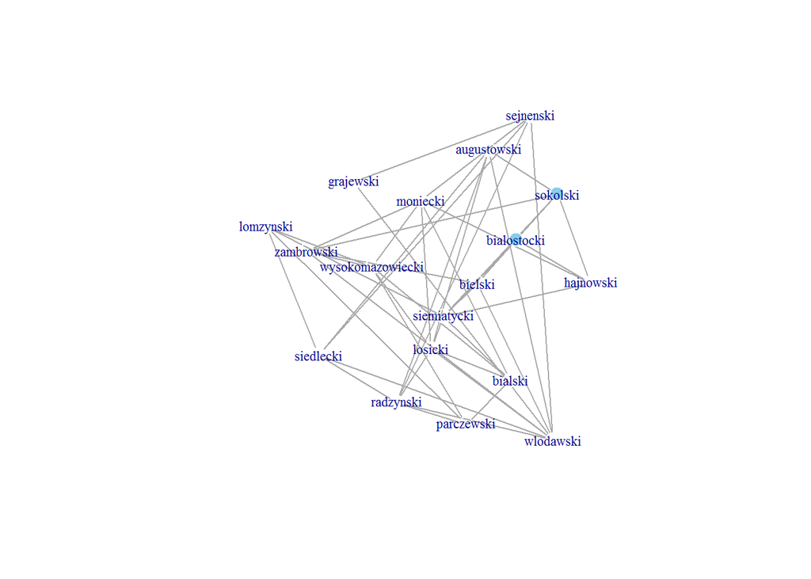

```r
# first year of outbreak
for (i in 1:length(list[,1])) {
  if (list$arrival_time[i]<365) {
    V(net)[i]$first=1
  }
}
plot.igraph(net, vertex.size=9, vertex.label=V(net)$names, vertex.label.cex=0.7, edge.arrow.size=0.3, vertex.color=c( "pink", "skyblue")[1+(V(net)$first==1)], layout=lay )
```

We can also use the metrcis to inspect the relationship between the role and group of the actors and the topology of the network.

```r
# Density
# The proportion of present edges from all possible ties.
edge_density(net, loops=F)
```

```
## [1] 0.1503268
```

```r
ecount(net)/(vcount(net)*(vcount(net)-1)) #for a directed network
```

```
## [1] 0.1503268
```

```r
# Reciprocity
# The proportion of reciprocated ties (for a directed network).
reciprocity(net)
```

```
## [1] 0
```

```r
dyad_census(net) # Mutual, asymmetric, and null node pairs
```

```
## $mut
## [1] 0
##
## $asym
## [1] 46
##
## $null
## [1] 107
```

```r
2*dyad_census(net)$mut/ecount(net) # Calculating reciprocity
```

```
## [1] 0
```

```r
# Transitivity
# global - ratio of triangles (direction disregarded) to connected triples
# local - ratio of triangles to connected triples each vertex is part of
transitivity(net, type="global")  # net is treated as an undirected network
```

```
## [1] 0.3640777
```

```r
transitivity(as.undirected(net, mode="collapse")) # same as above
```

```
## [1] 0.3640777
```

```r
transitivity(net, type="local")
```

```
##  [1] 0.6666667 0.3000000 0.5000000 0.2380952 0.5000000 0.2666667 0.3333333
##  [8] 0.4000000 0.2000000 0.3333333 0.3214286 0.4000000 1.0000000 0.4666667
## [15] 0.5000000 0.1666667 0.3333333 0.5000000
```

```r
triad_census(net) # for directed networks
```

```
##  [1] 261 399   0  33  22  76   0   0  25   0   0   0   0   0   0   0
```

Degree distribution often reveal interesting topological structure.

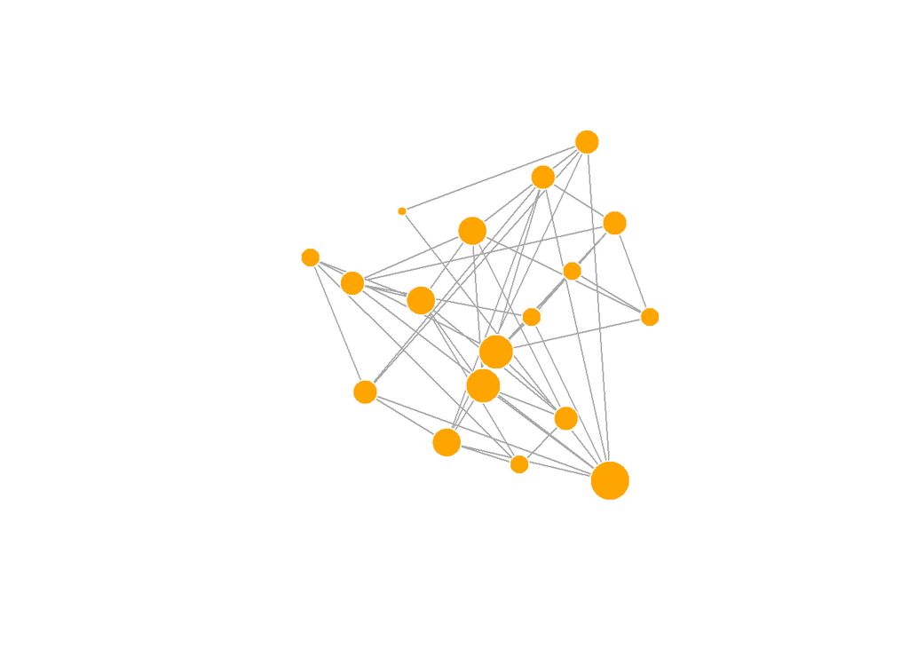

```r
# Node degrees
# 'degree' has a mode of 'in' for in-degree, 'out' for out-degree,
# and 'all' or 'total' for total degree.
deg <- degree(net, mode="all")
plot(net, vertex.size=deg*3)
```

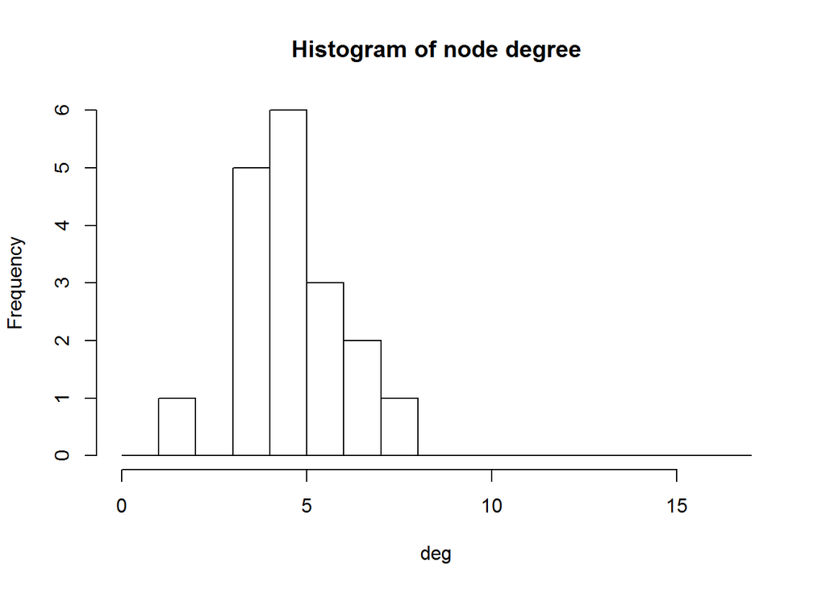

```r
hist(deg, breaks=1:vcount(net)-1, main="Histogram of node degree")
```

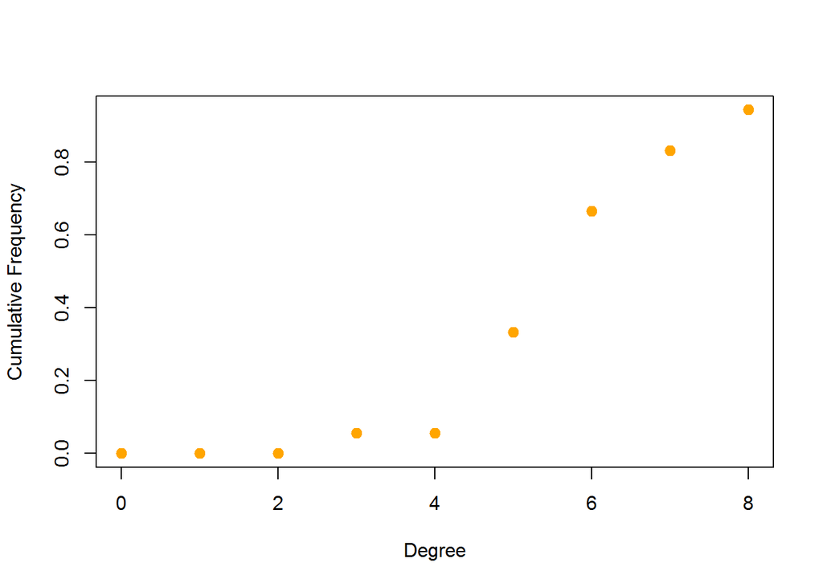

```r
# Degree distribution
deg.dist <- degree_distribution(net, cumulative=T, mode="all")
plot( x=0:max(deg), y=1-deg.dist, pch=19, cex=1.2, col="orange",
      xlab="Degree", ylab="Cumulative Frequency")
```

Centrality functions (vertex level) and centralization functions (graph level)

```r
# Degree (number of ties)
degree(net, mode="in")
```

```
##  [1] 0 1 2 3 1 2 3 3 3 3 3 2 2 3 3 3 4 5
```

```r
centr_degree(net, mode="in", normalized=T)
```

```
## $res
##  [1] 0 1 2 3 1 2 3 3 3 3 3 2 2 3 3 3 4 5
##
## $centralization
## [1] 0.1437908
##
## $theoretical_max
## [1] 306
```

```r
# Closeness (centrality based on distance to others in the graph)
# Inverse of the node's average geodesic distance to others in the network
closeness(net, mode="all", weights = NA)
```

```
##  [1] 0.02777778 0.03125000 0.02857143 0.03448276 0.03225806 0.03571429
##  [7] 0.03703704 0.03333333 0.03448276 0.03225806 0.03703704 0.03125000
## [13] 0.02500000 0.03333333 0.03125000 0.03225806 0.02857143 0.03448276
```

```r
centr_clo(net, mode="all", normalized = T)
```

```
## $res
##  [1] 0.4722222 0.5312500 0.4857143 0.5862069 0.5483871 0.6071429 0.6296296
##  [8] 0.5666667 0.5862069 0.5483871 0.6296296 0.5312500 0.4250000 0.5666667
## [15] 0.5312500 0.5483871 0.4857143 0.5862069
##
## $centralization
## [1] 0.178032
##
## $theoretical_max
## [1] 8.242424
```

```r
# Eigenvector (centrality proportional to the sum of connection centralities)
# Values of the first eigenvector of the graph adjacency matrix
eigen_centrality(net, directed = T, weights = NA)
```

[output not shown]

[output cut: 11 more lines]

```
##
## $options$iter
## [1] 1000
##
## $options$nconv
## [1] 0
##
## $options$numop
## [1] 0
##
## $options$numopb
## [1] 0
##
## $options$numreo
## [1] 0
```

```r
centr_eigen(net, directed = T, normalized=T)
```

[output not shown]

[output cut: 18 more lines]

```
## $options$numop
## [1] 0
##
## $options$numopb
## [1] 0
##
## $options$numreo
## [1] 0
##
##
## $centralization
## [1] 0
##
## $theoretical_max
## [1] 17
```

```r
# Betweenness (centrality based on a broker position connecting others)
# (Number of geodesics that pass through the node or the edge)
betweenness(net, directed=T, weights=NA)
```

```
##  [1]  0.000000  2.000000  3.666667 16.333333  5.000000 12.666667 14.833333
##  [8]  8.500000 15.250000  5.916667 30.666667  5.666667  0.000000  6.166667
## [15]  5.500000  2.833333  0.000000  0.000000
```

```r
edge_betweenness(net, directed=T, weights=NA)
```

```
##  [1]  3.000000  2.833333  6.166667  5.000000  2.833333  6.666667  6.500000
##  [8]  2.000000  6.500000 12.166667  9.000000 11.083333  4.416667  5.833333
## [15]  5.500000  5.166667  4.500000  2.833333  4.583333  5.000000  5.083333
## [22] 10.000000  6.000000  8.000000  6.833333  5.000000 11.666667  4.000000
## [29]  2.833333  5.500000 18.750000 13.916667  6.666667  8.500000  8.000000
## [36] 10.500000  4.000000  3.500000  3.333333  4.833333  3.166667  5.500000
## [43]  1.500000  7.000000  1.500000  3.833333
```

```r
centr_betw(net, directed=T, normalized=T)
```

```
## $res
##  [1]  0.000000  2.000000  3.666667 16.333333  5.000000 12.666667 14.833333
##  [8]  8.500000 15.250000  5.916667 30.666667  5.666667  0.000000  6.166667
## [15]  5.500000  2.833333  0.000000  0.000000
##
## $centralization
## [1] 0.09018166
##
## $theoretical_max
## [1] 4624
```

To compute effective distances, we can use paths detecting algorithms.

```r
# Average path length
# The mean of the shortest distance between each pair of nodes in the network
# (in both directions for directed graphs).
mean_distance(net, directed=F)
```

```
## [1] 1.843137
```

```r
mean_distance(net, directed=T)
```

```
## [1] 1.924658
```

```r
# We can also find the length of all shortest paths in the graph:
distances(net) # with edge weights
```

```
##       [,1] [,2] [,3] [,4] [,5] [,6] [,7] [,8] [,9] [,10] [,11] [,12] [,13]
##  [1,]    0    3    2    2    4    3    3    4    4     1     4     4     5
##  [2,]    3    0    3    1    3    2    2    3    1     2     2     3     4
##  [3,]    2    3    0    2    3    1    3    2    2     3     3     2     3
##  [4,]    2    1    2    0    2    3    1    2    2     1     2     4     5
##  [5,]    4    3    3    2    0    2    1    1    3     3     2     3     4
##  [6,]    3    2    1    3    2    0    3    1    1     4     2     1     2
##  [7,]    3    2    3    1    1    3    0    2    2     2     1     3     4
##  [8,]    4    3    2    2    1    1    2    0    2     3     3     2     3
##  [9,]    4    1    2    2    3    1    2    2    0     3     1     2     3
## [10,]    1    2    3    1    3    4    2    3    3     0     3     5     6
## [11,]    4    2    3    2    2    2    1    3    1     3     0     2     3
## [12,]    4    3    2    4    3    1    3    2    2     5     2     0     1
## [13,]    5    4    3    5    4    2    4    3    3     6     3     1     0
## [14,]    4    2    4    2    2    3    1    2    3     3     2     2     3
```

[output cut: 23 more lines]

```r
distances(net, weights=NA) # ignore weights
```

```
##       [,1] [,2] [,3] [,4] [,5] [,6] [,7] [,8] [,9] [,10] [,11] [,12] [,13]
##  [1,]    0    1    1    1    2    2    2    3    2     1     2     3     3
##  [2,]    1    0    1    1    2    2    2    2    1     2     2     3     3
##  [3,]    1    1    0    1    2    1    2    2    2     2     3     2     3
##  [4,]    1    1    1    0    1    2    1    2    2     1     2     3     3
##  [5,]    2    2    2    1    0    1    1    1    2     2     2     2     3
##  [6,]    2    2    1    2    1    0    1    1    1     2     2     1     2
##  [7,]    2    2    2    1    1    1    0    1    2     2     1     2     2
##  [8,]    3    2    2    2    1    1    1    0    1     2     2     2     3
##  [9,]    2    1    2    2    2    1    2    1    0     1     1     2     2
## [10,]    1    2    2    1    2    2    2    2    1     0     1     2     2
## [11,]    2    2    3    2    2    2    1    2    1     1     0     1     1
## [12,]    3    3    2    3    2    1    2    2    2     2     1     0     1
## [13,]    3    3    3    3    3    2    2    3    2     2     1     1     0
## [14,]    3    2    3    2    2    2    1    2    2     2     1     1     2
```

[output cut: 23 more lines]

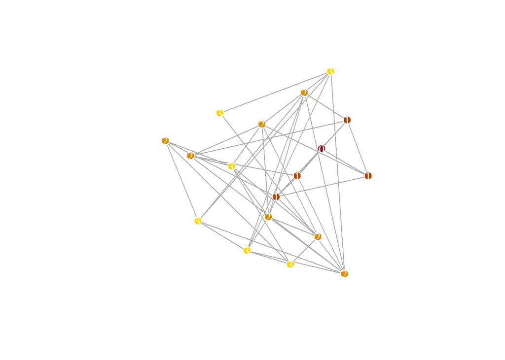

```r
# We can extract the distances to a node or set of nodes we are interested in.
# Here we will get the distance of every counte from the first affected - bialostocki county.
dist.from.bialystok <- distances(net, v=V(net)[names=="bialostocki"], to=V(net), weights=NA)

# Set colors to plot the distances:
oranges <- colorRampPalette(c("dark red", "gold"))
col <- oranges(max(dist.from.bialystok)+1)
col <- col[dist.from.bialystok+1]

plot(net, vertex.color=col, vertex.label=dist.from.bialystok, edge.arrow.size=.6,
     vertex.label.color="white")
```

```r
# We can also find the shortest path between specific nodes.
# Say here between bialski county (main regional hub for pig production) with source (first affected county):
infection.path <- shortest_paths(net,
                            from = V(net)[names=="bialostocki"],
                            to  = V(net)[names=="bialski"],
                            output = "both") # both path nodes and edges
infection.path
```

```
## $vpath
## $vpath[[1]]
## + 3/18 vertices, from de88bf1:
## [1] 1 4 5
##
##
## $epath
## $epath[[1]]
## + 2/46 edges from de88bf1:
## [1] 1->4 4->5
##
##
## $predecessors
## NULL
##
## $inbound_edges
## NULL
```

```r
res <- sir(net, beta=5, gamma=1, no.sim=10)
```

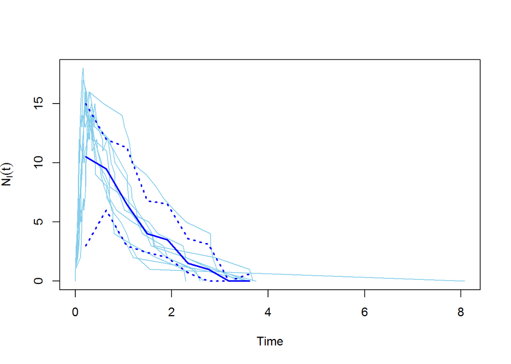

```r
plot(res)
```

SIR Stochastic model on network

```r
res <- sir(net, beta=5, gamma=1, no.sim=10)
```

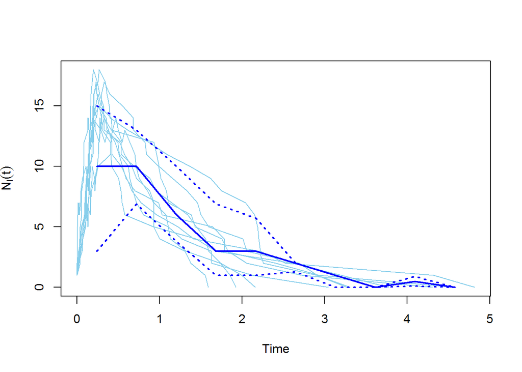

```r
plot(res)
```

# 2 Modeling Spreading Processes on Networks

The objective of this part is to understand the spreading processes on networks.

We introduce here so-called compartmental epidemiological models.

## 2.1 Susceptible-Infected (SI) model

In this model the compartment of Susceptibles could be infected with a reaction rate $\beta$. This could be described by this kinetic equation:

$$I + S\stackrel{\alpha}{\longrightarrow}2I.$$
The corresponding mean-field deterministic equation under assumption of well-mixed population reads:

$$\frac{dS}{dt} = -\alpha\frac{SI}{N}\\
\frac{dI}{dt} = \alpha\frac{SI}{N},$$
where $N$ is a total number of individuals (hosts) in a population.

Below we implement this equation in R and plot the dependence of the number of infecteds vs time.

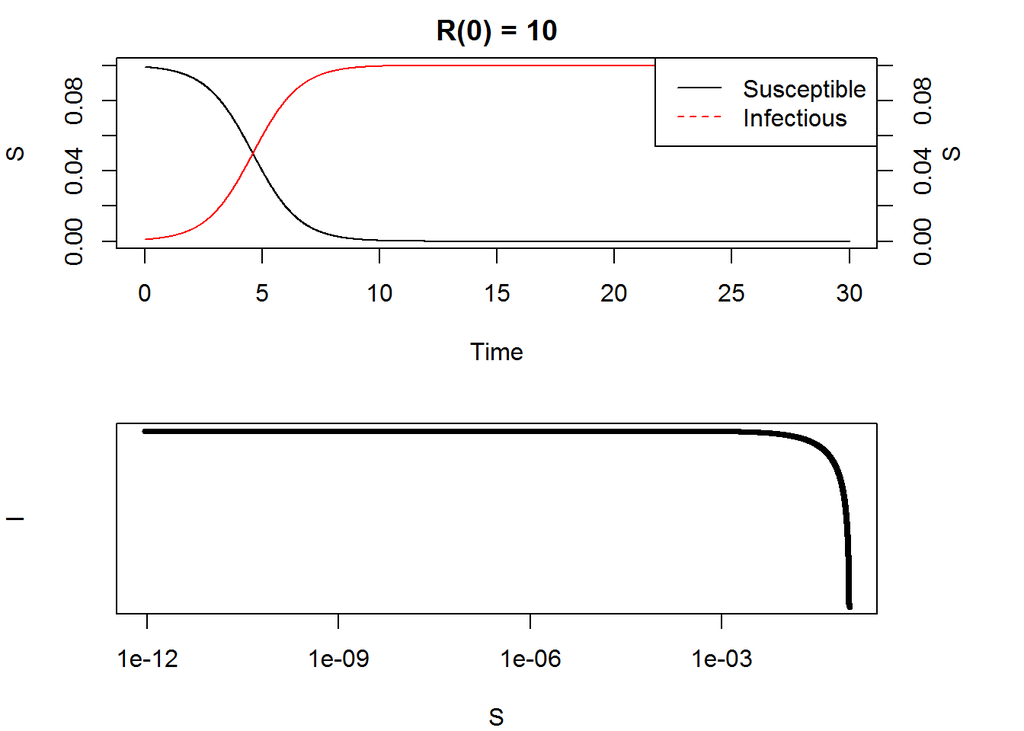

```r
# the code was inspired by https://ms.mcmaster.ca/~bolker/eeid/2011_eco/EEID2011_Simulation.pdf
si.model <- function (t, x, params) {
  S <- x[1]
  I <- x[2]

  with(
    #susceptibles
    #infected
    #recovered
    as.list(params), #local environment to evaluate derivatives
    {
      dS <- -beta*S*I/N
      dI <- beta*S*I/N
      dx <- c(dS,dI)
      list(dx)
    }
  )
}


times <- seq(0,30,by=1/120)
params <- c(N=1,beta=10)
xstart <- c(S=1-0.001-0.9,I=0.001)
R0 <- function(params) with(as.list(params), beta)
out <- as.data.frame(deSolve::ode(xstart,times,si.model,params))

op <- par(fig=c(0,1,0,0.5),mar=c(4,4,2,5))
plot(I~S,data=out,type='b',log='xy',yaxt='n',xlab='S',cex=0.5)
par(fig=c(0,1,0.5,1),mar=c(4,4,2,5), new=TRUE)
plot(S~time,data=out,type='l', ylim=c(0,0.1), xlab='Time',main=paste('R(0) =', round(R0(params),2)))
lines(I~time,data=out,type='l',col='red'); par(new=TRUE)

axis(4)
mtext('S', side=4, line=2)
legend('topright', legend=c('Susceptible', 'Infectious'), col=c('black','red'), lty = 1:2, lt > par(op))
```

## 2.2 Susceptible-Recovered Model

Now we introduce recovery (or removal, e.g. death). The kinetic equation reads:

$$\frac{dS}{dt} = -\alpha\frac{SI}{N}\\
\frac{dI}{dt} = \alpha\frac{SI}{N}-\gamma I\\
\frac{dR}{dt} = \gamma I,$$

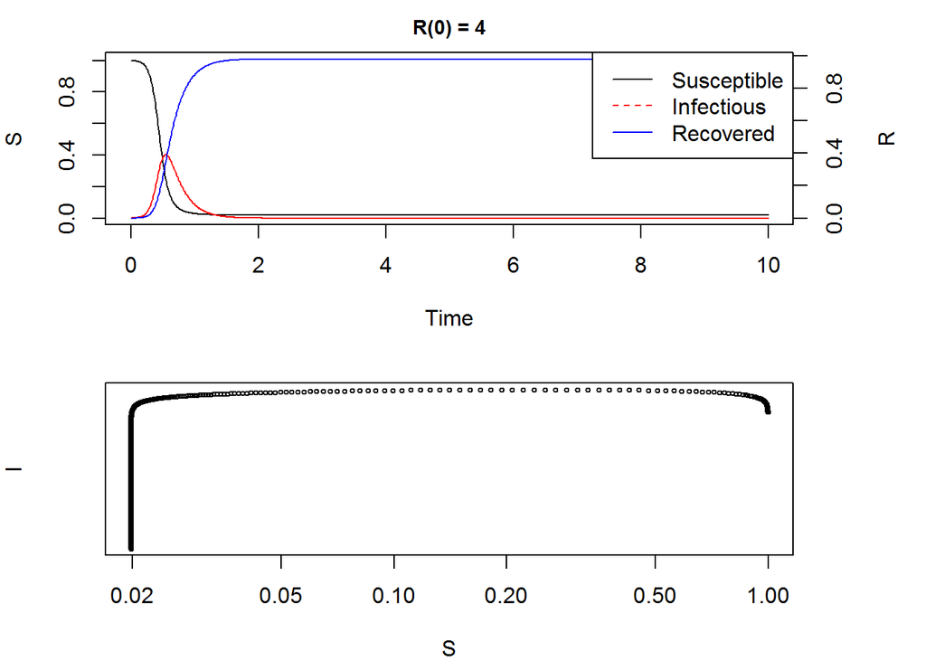

```r
sir.model <- function (t, x, params) {
  S <- x[1]
  I <- x[2]
  R <- x[3]
  with(
    #susceptibles
    #infected
    #recovered
    as.list(params), #local environment to evaluate derivatives
    {
      dS <- -beta*S*I/N
      dI <- beta*S*I/N-gamma*I
      dR <- gamma*I
      dx <- c(dS,dI,dR)
      list(dx)
    }
  )
}


times <- seq(0,10,by=1/120) # setting the time of simulations
params <- c(N=1, beta=20, gamma=5)
xstart <- c(S=1-0.001-0.0,I=0.001,R=0.0)
R0 <- function(params) with (as.list(params), beta/(gamma))
out <- as.data.frame(deSolve::ode(xstart,times,sir.model,params))

op <- par(fig=c(0,1,0,0.5),mar=c(4,4,2,5))
plot(I~S,data=out,type='b',log='xy',yaxt='n',xlab='S',cex=0.5)
par(fig=c(0,1,0.5,1),mar=c(4,4,2,5), new=TRUE)
plot(S~time,data=out, type='l', ylim=c(0,max(S)+0.01), xlab='Time')
lines(I~time,data=out, type='l',col='red'); par(new=TRUE)
plot(R~time,data=out, type='l', ylim=c(min(R),max(R)), col='blue', axes=FALSE, xlab='', ylab='', main=paste('R(0) =',round(R0(params),2)), cex.main=0.9)
axis(4)
mtext('R', side=4, line=3)
legend('topright', legend=c('Susceptible', 'Infectious', 'Recovered'), col=c('black','red','blue'), lty = 1:2, lt > par(op))
```

## 2.3 SI epidemic on a random network

```r
# u = c(1,3,4,5)
# v = c(2,1,2,3)
# print("x")
# print(x)

# -----------------------
N = 40 #graphsize
M = 20 #number of edges
T = 8 # maximal obervation time
alpha = 0.8 # infection probability (per time unit)
# set.seed(111)

# two random sequences for head and tail vertices in the edges are produced
v <- sample(1:N, M, replace = TRUE)
u <- sample(1:N, M, replace = TRUE)

print(length(unique(c(v,u))))
```

```
## [1] 25
```

```r
# what if one number is missing?
# x = rep(0,length(unique(c(u,v))))
x = rep(0,N)
x[1] = 1

print(x)
```

```
##  [1] 1 0 0 0 0 0 0 0 0 0 0 0 0 0 0 0 0 0 0 0 0 0 0 0 0 0 0 0 0 0 0 0 0 0 0
## [36] 0 0 0 0 0
```

```
## [1] "x_next"
##  [1] 1 1 0 0 0 0 0 0 0 0 0 0 0 0 0 0 0 0 0 0 0 0 0 0 0 0 0 0 0 0 0 0 0 0 0
## [36] 0 0 0 0 0
## [1]  1 40
```

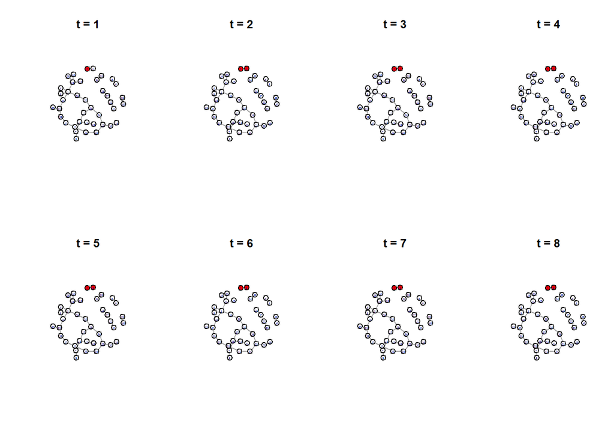

```r
x_next = x

# Creating graph
g <- graph( c(1:N), directed=FALSE )
# g <- graph_from_edgelist(cbind(u,v), directed = FALSE)
g <- add.edges(g,cbind(u,v))

# get rid of multiple edges and loops
g1 <- simplify(g)
V(g1)$label.cex = 0.3 # scaling the size of the vertex label font
#l1 <- layout_in_circle(g1)

u <- as_edgelist(g1)[,1]
v <- as_edgelist(g1)[,2]
l1 <- layout_with_fr(g1)
# V(g)$color = NULL
# > plot(g1, layout=l, vertex.size=20)

par( mfrow = c(2,4) ) # frames for plots

inf <- sum(x)

for (t in 1:T){
  if (t %% 1 == 0){
    for (j in 1:length(x)){
      if (x[j] == 1){
        V(g1)[j]$color<-"red" # assigning color to infected nodes
      }
    }

    # ploting the graph with infected vertices
    plot(g1, layout=l1, vertex.size = 15, main=paste('t =',as.character(t)))

  }

  for (i in 1:length(u)){
    n = u[i]
    m = v[i]


    if ((x[n] == 1) & (x[m] == 0) & (runif(1) < alpha)) {

      x_next[m] = 1
      print("x_next")
      print(x_next)
      print(c(u[i],v[j]))
    }
    if ((x[m] == 1) & (x[n] == 0) & (runif(1) < alpha)){
      x_next[n] = 1
    }
  }
  x = x_next
  inf <- cbind(inf,sum(x))
}
```

# 3 Case Study: African Swine Fever in Poland

Plotting on the map

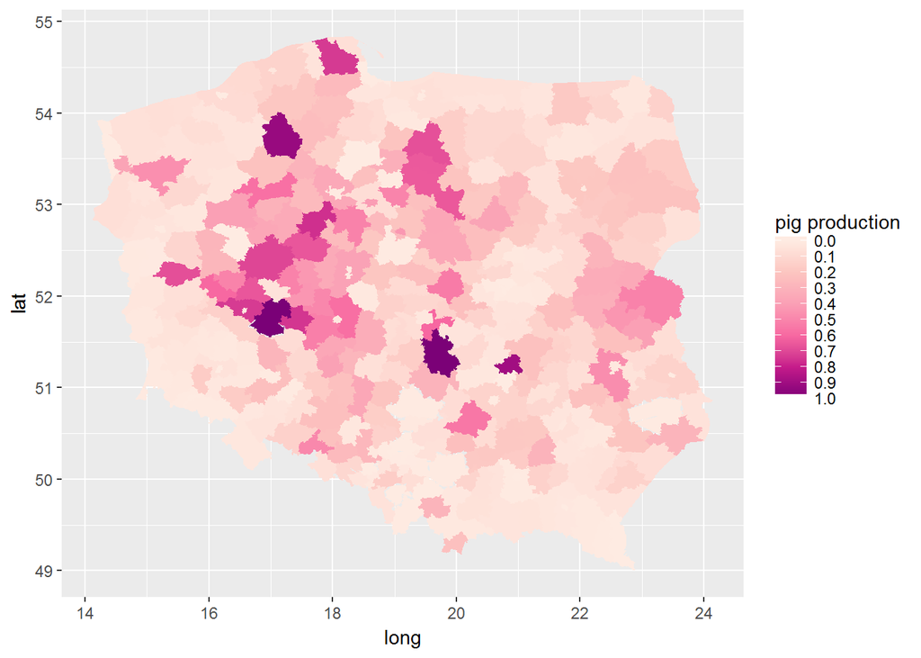

```r
map <- inner_join(Map_poland, counties_data, by = c("id" = "map_id_0"))

p<-ggplot(data = map, mapping = aes(x = long, y = lat)) +
  geom_polygon(mapping = aes(group = group, fill = pig))+
  scale_fill_distiller("pig production", palette = "RdPu", breaks = pretty_breaks(n = 8), trans = "reverse")
p
```

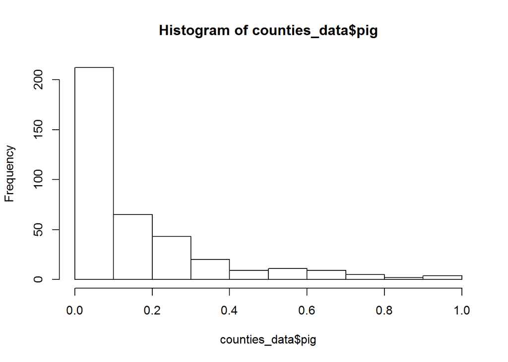

```r
hist(counties_data$pig)
```

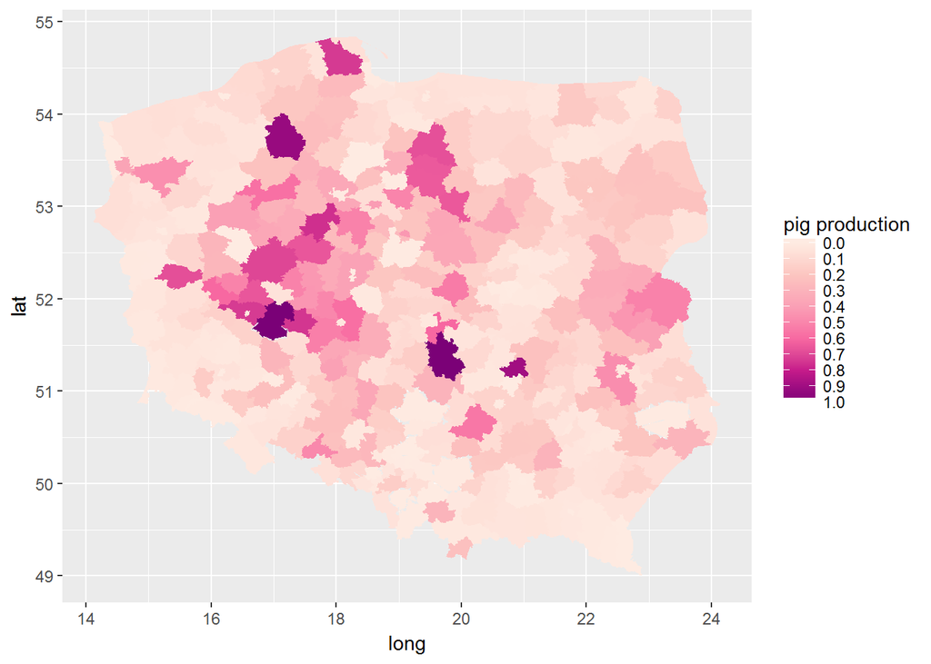

```r
p<-ggplot(data = map, mapping = aes(x = long, y = lat)) +
  geom_polygon(mapping = aes(group = group, fill = pig))+
  scale_fill_distiller("pig production", palette = "RdPu", breaks = pretty_breaks(n = 8), trans = "reverse")
p
```

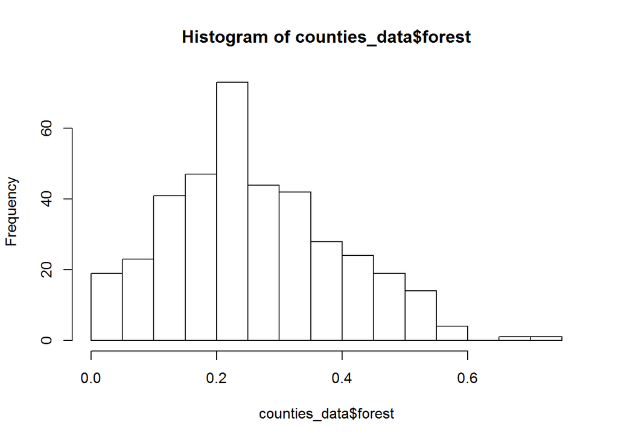

```r
hist(counties_data$forest)
```

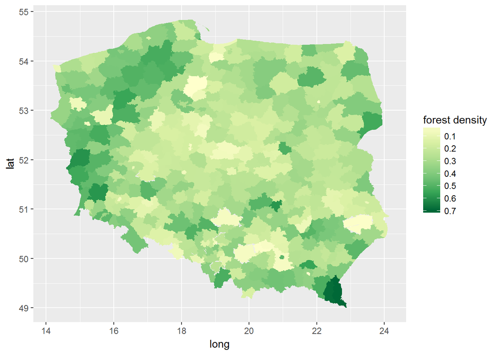

```r
p<-ggplot(data = map, mapping = aes(x = long, y = lat)) +
  geom_polygon(mapping = aes(group = group, fill = forest))+
  scale_fill_distiller("forest density", palette = "YlGn", breaks = pretty_breaks(n = 8), trans = "reverse")
p
```

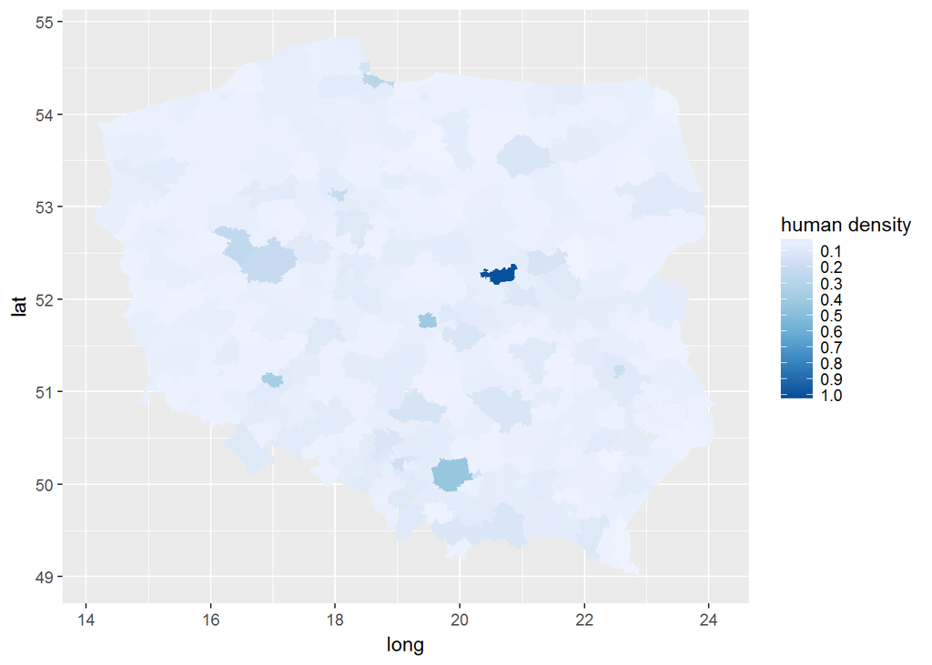

```r
p<-ggplot(data = map, mapping = aes(x = long, y = lat)) +
  geom_polygon(mapping = aes(group = group, fill = hum))+
  scale_fill_distiller("human density", breaks = pretty_breaks(n = 8), trans = "reverse")
#linaer
p
```

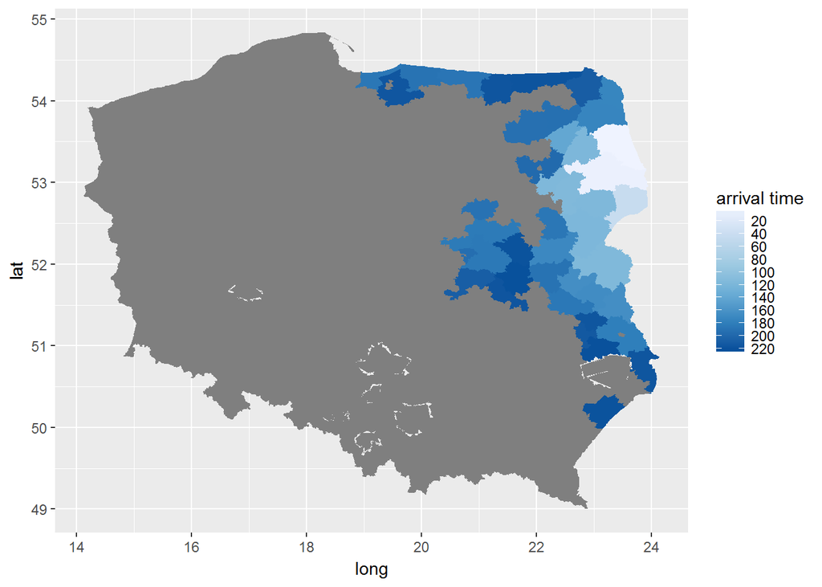

```r
p<-ggplot(data = map, mapping = aes(x = long, y = lat)) +
  geom_polygon(mapping = aes(group = group, fill = hum))+
  scale_fill_distiller("human density", breaks = pretty_breaks(n = 8), trans = "reverse")

# in log scale?

p<-ggplot(data = map, mapping = aes(x = long, y = lat)) +
  geom_polygon(mapping = aes(group = group, fill = arrival_time))+
  scale_fill_distiller("arrival time", breaks = pretty_breaks(n = 8), trans = "reverse")

p
```

```r
 fst=0.3
 scale=0.18
 hum=0.6
 pork=0.7
p1=matrix(0, nrow=380, ncol = 380)


  for (i in 1:379){
    for (j in (i+1):380) {
p1[i,j]=scale*(hum*(counties_data$hum[i]*counties_data$hum[j])/(1+distance_C[i,j])+pork*(counties_data$pig[i]*counties_data$pig[j])/(1+distance_C[i,j])+fst*counties_data$forest[i]*counties_data$forest[j]/(1+distance_C[i,j])^2)
p1[j,i]=p1[i,j]
    }
  }
Poland_fully=graph_from_adjacency_matrix(p1,  weighted=TRUE)
write.csv(p1, file="Pol_fully.csv")

read_file=read.csv("Pol_fully.csv", header = FALSE)
#treshold
E(Poland_fully)
```

```
## + 144020/144020 edges from f208cad:
##   [1] 1->  2 1->  3 1->  4 1->  5 1->  6 1->  7 1->  8 1->  9 1-> 10 1-> 11
##  [11] 1-> 12 1-> 13 1-> 14 1-> 15 1-> 16 1-> 17 1-> 18 1-> 19 1-> 20 1-> 21
##  [21] 1-> 22 1-> 23 1-> 24 1-> 25 1-> 26 1-> 27 1-> 28 1-> 29 1-> 30 1-> 31
##  [31] 1-> 32 1-> 33 1-> 34 1-> 35 1-> 36 1-> 37 1-> 38 1-> 39 1-> 40 1-> 41
##  [41] 1-> 42 1-> 43 1-> 44 1-> 45 1-> 46 1-> 47 1-> 48 1-> 49 1-> 50 1-> 51
##  [51] 1-> 52 1-> 53 1-> 54 1-> 55 1-> 56 1-> 57 1-> 58 1-> 59 1-> 60 1-> 61
##  [61] 1-> 62 1-> 63 1-> 64 1-> 65 1-> 66 1-> 67 1-> 68 1-> 69 1-> 70 1-> 71
##  [71] 1-> 72 1-> 73 1-> 74 1-> 75 1-> 76 1-> 77 1-> 78 1-> 79 1-> 80 1-> 81
##  [81] 1-> 82 1-> 83 1-> 84 1-> 85 1-> 86 1-> 87 1-> 88 1-> 89 1-> 90 1-> 91
##  [91] 1-> 92 1-> 93 1-> 94 1-> 95 1-> 96 1-> 97 1-> 98 1-> 99 1->100 1->101
## + ... omitted several edges
```

```r
Poland_smaller=delete.edges(Poland_fully, which(E(Poland_fully)$weight<0.005))
E(Poland_smaller)
```

```
## + 6912/6912 edges from f37c366:
##   [1] 2->203 3->279 4->  5 4->  6 4->  8 4->  9 4-> 12 4-> 14 4-> 16 4-> 21
##  [11] 4-> 33 4-> 38 4-> 54 4-> 55 4-> 57 4-> 67 4-> 69 4-> 74 4-> 78 4-> 80
##  [21] 4-> 85 4-> 86 4-> 88 4-> 93 4-> 94 4-> 96 4-> 99 4->111 4->113 4->114
##  [31] 4->122 4->124 4->134 4->171 4->180 4->187 4->197 4->198 4->205 4->206
##  [41] 4->211 4->212 4->217 4->221 4->243 4->253 4->256 4->257 4->272 4->276
##  [51] 4->277 4->282 4->293 4->298 4->300 4->305 4->311 4->317 4->321 4->323
##  [61] 4->325 4->337 4->339 4->346 4->348 4->350 4->351 4->359 4->361 4->368
##  [71] 4->370 5->  4 5->  8 5->  9 5-> 14 5-> 16 5-> 33 5-> 35 5-> 67 5-> 74
##  [81] 5-> 85 5-> 86 5-> 96 5->113 5->114 5->122 5->134 5->172 5->180 5->206
##  [91] 5->243 5->253 5->272 5->276 5->282 5->298 5->317 5->346 5->348 6->  4
## + ... omitted several edges
```

```r
V(Poland_smaller)$names=counties_data$county
```

Infections paths

```r
infection.path1 <- shortest_paths(Poland_smaller,
                            from = V(Poland_smaller)[names=="bialostocki"],
                            to  = V(Poland_smaller)[names=="gostynski"],
                            output = "both") # both path nodes and edges
infection.path1
```

```
## $vpath
## $vpath[[1]]
## + 3/380 vertices, from f37c366:
## [1]  29 344  74
##
##
## $epath
## $epath[[1]]
## + 2/6912 edges from f37c366:
## [1]  29->344 344-> 74
##
##
## $predecessors
## NULL
##
## $inbound_edges
## NULL
```

```r
#delete parczewski county (sanitary cordon)
Poland_mitigation=delete.vertices(Poland_smaller, 344)



infection.path2 <- shortest_paths(Poland_mitigation,
                            from = V(Poland_mitigation)[names=="bialostocki"],
                            to  = V(Poland_mitigation)[names=="gostynski"],
                            output = "both") # both path nodes and edges
infection.path2
```

```
## $vpath
## $vpath[[1]]
## + 3/379 vertices, from f394047:
## [1] 29 53 74
##
##
## $epath
## $epath[[1]]
## + 2/6836 edges from f394047:
## [1] 29->53 53->74
##
##
## $predecessors
## NULL
##
## $inbound_edges
## NULL
```

Understanding strategies

```r
linear_arrival=lm(arrival_time~hum+forest+pig+forest*hum+pig*forest+pig*hum, data =counties_data)
anova(linear_arrival)
```

```
## Analysis of Variance Table
##
## Response: arrival_time
##            Df Sum Sq Mean Sq F value  Pr(>F)
## hum         1    454   454.4  0.1795 0.67394
## forest      1   6570  6569.6  2.5949 0.11453
## pig         1  11235 11234.5  4.4374 0.04103 *
## hum:forest  1    408   407.6  0.1610 0.69024
## forest:pig  1   1250  1250.2  0.4938 0.48602
## hum:pig     1     82    81.7  0.0323 0.85828
## Residuals  43 108866  2531.8
## ---
## Signif. codes:  0 '***' 0.001 '**' 0.01 '*' 0.05 '.' 0.1 ' ' 1
```

Other mitigation strategies?